title: “Devoir 05 - Santé mentale dans le secteur technologique” author: “Robinson Cacquevel” date: “22/10/2025” output: github_document —

## 1. Introduction

Dans ce projet, nous analysons les données du sondage **“Mental Health in Tech Survey”** (Kaggle) portant sur la santé mentale de personnes travaillant dans le secteur technologique.

Nous nous concentrons sur deux questions de recherche :

1. **Accès au traitement (Q1)** : Quels facteurs personnels et professionnels sont associés au fait d’avoir déjà reçu un **traitement** pour un problème de santé mentale (`treatment`, Yes/No) ?
2. **Interférence avec le travail (Q2)** : Dans quelle mesure la santé mentale **interfère avec le travail** (`work_interfere`) et comment ce niveau d’interférence est-il lié aux **politiques et au climat de l’entreprise** (bénéfices, options de soins, anonymat, etc.) ?

## 2. Données

```r
library(tidyverse)
library(skimr)
library(janitor)
df <- readRDS("data/mental_health.rds") |> clean_names()
```

Le jeu de données contient 1259 observations et 27 variables.

```r
glimpse(df)
```

```
## Rows: 1,259
## Columns: 27
## $ timestamp                 <dttm> 2014-08-27 11:29:31, 2014-08-27 11:29:37, 2…
## $ age                       <dbl> 37, 44, 32, 31, 31, 33, 35, 39, 42, 23, 31, …
## $ gender                    <chr> "Female", "M", "Male", "Male", "Male", "Male…
## $ country                   <chr> "United States", "United States", "Canada", …
## $ state                     <chr> "IL", "IN", NA, NA, "TX", "TN", "MI", NA, "I…
## $ self_employed             <chr> NA, NA, NA, NA, NA, NA, NA, NA, NA, NA, NA, …
## $ family_history            <chr> "No", "No", "No", "Yes", "No", "Yes", "Yes",…
## $ treatment                 <chr> "Yes", "No", "No", "Yes", "No", "No", "Yes",…
## $ work_interfere            <chr> "Often", "Rarely", "Rarely", "Often", "Never…
## $ no_employees              <chr> "6-25", "More than 1000", "6-25", "26-100", …
## $ remote_work               <chr> "No", "No", "No", "No", "Yes", "No", "Yes", …
## $ tech_company              <chr> "Yes", "No", "Yes", "Yes", "Yes", "Yes", "Ye…
## $ benefits                  <chr> "Yes", "Don't know", "No", "No", "Yes", "Yes…
## $ care_options              <chr> "Not sure", "No", "No", "Yes", "No", "Not su…
## $ wellness_program          <chr> "No", "Don't know", "No", "No", "Don't know"…
## $ seek_help                 <chr> "Yes", "Don't know", "No", "No", "Don't know…
## $ anonymity                 <chr> "Yes", "Don't know", "Don't know", "No", "Do…
## $ leave                     <chr> "Somewhat easy", "Don't know", "Somewhat dif…
## $ mental_health_consequence <chr> "No", "Maybe", "No", "Yes", "No", "No", "May…
## $ phys_health_consequence   <chr> "No", "No", "No", "Yes", "No", "No", "Maybe"…
## $ coworkers                 <chr> "Some of them", "No", "Yes", "Some of them",…
## $ supervisor                <chr> "Yes", "No", "Yes", "No", "Yes", "Yes", "No"…
## $ mental_health_interview   <chr> "No", "No", "Yes", "Maybe", "Yes", "No", "No…
## $ phys_health_interview     <chr> "Maybe", "No", "Yes", "Maybe", "Yes", "Maybe…
## $ mental_vs_physical        <chr> "Yes", "Don't know", "No", "No", "Don't know…
## $ obs_consequence           <chr> "No", "No", "No", "Yes", "No", "No", "No", "…
## $ comments                  <chr> NA, NA, NA, NA, NA, NA, NA, NA, NA, NA, NA, …
```

```r
skim(df)
```

Data summary

| Name | df |
| --- | --- |
| Number of rows | 1259 |
| Number of columns | 27 |
| _______________________ |  |
| Column type frequency: |  |
| character | 25 |
| numeric | 1 |
| POSIXct | 1 |
| ________________________ |  |
| Group variables | None |

**Variable type: character**

| skim_variable | n_missing | complete_rate | min | max | empty | n_unique | whitespace |
| --- | --- | --- | --- | --- | --- | --- | --- |
| gender | 0 | 1.00 | 1 | 46 | 0 | 47 | 0 |
| country | 0 | 1.00 | 5 | 22 | 0 | 48 | 0 |
| state | 515 | 0.59 | 2 | 2 | 0 | 45 | 0 |
| self_employed | 18 | 0.99 | 2 | 3 | 0 | 2 | 0 |
| family_history | 0 | 1.00 | 2 | 3 | 0 | 2 | 0 |
| treatment | 0 | 1.00 | 2 | 3 | 0 | 2 | 0 |
| work_interfere | 264 | 0.79 | 5 | 9 | 0 | 4 | 0 |
| no_employees | 0 | 1.00 | 3 | 14 | 0 | 6 | 0 |
| remote_work | 0 | 1.00 | 2 | 3 | 0 | 2 | 0 |
| tech_company | 0 | 1.00 | 2 | 3 | 0 | 2 | 0 |
| benefits | 0 | 1.00 | 2 | 10 | 0 | 3 | 0 |
| care_options | 0 | 1.00 | 2 | 8 | 0 | 3 | 0 |
| wellness_program | 0 | 1.00 | 2 | 10 | 0 | 3 | 0 |
| seek_help | 0 | 1.00 | 2 | 10 | 0 | 3 | 0 |
| anonymity | 0 | 1.00 | 2 | 10 | 0 | 3 | 0 |
| leave | 0 | 1.00 | 9 | 18 | 0 | 5 | 0 |
| mental_health_consequence | 0 | 1.00 | 2 | 5 | 0 | 3 | 0 |
| phys_health_consequence | 0 | 1.00 | 2 | 5 | 0 | 3 | 0 |
| coworkers | 0 | 1.00 | 2 | 12 | 0 | 3 | 0 |
| supervisor | 0 | 1.00 | 2 | 12 | 0 | 3 | 0 |
| mental_health_interview | 0 | 1.00 | 2 | 5 | 0 | 3 | 0 |
| phys_health_interview | 0 | 1.00 | 2 | 5 | 0 | 3 | 0 |
| mental_vs_physical | 0 | 1.00 | 2 | 10 | 0 | 3 | 0 |
| obs_consequence | 0 | 1.00 | 2 | 3 | 0 | 2 | 0 |
| comments | 1096 | 0.13 | 1 | 3548 | 0 | 159 | 0 |

**Variable type: numeric**

| skim_variable | n_missing | complete_rate | mean | sd | p0 | p25 | p50 | p75 | p100 | hist |
| --- | --- | --- | --- | --- | --- | --- | --- | --- | --- | --- |
| age | 0 | 1 | 79428148 | 2818299443 | -1726 | 27 | 31 | 36 | 1e+11 | ▇▁▁▁▁ |

**Variable type: POSIXct**

| skim_variable | n_missing | complete_rate | min | max | median | n_unique |
| --- | --- | --- | --- | --- | --- | --- |
| timestamp | 0 | 1 | 2014-08-27 11:29:31 | 2016-02-01 23:04:31 | 2014-08-28 02:30:00 | 1246 |

Les variables comprennent des informations démographiques (`age`, `gender`, `country`, `no_employees`, `self_employed`), des indicateurs de santé mentale (`treatment`, `family_history`, `work_interfere`) et des variables décrivant les politiques de l’entreprise (`benefits`, `care_options`, `anonymity`, etc.).

## 3. Méthodes

```r
load("data/eda_objects.RData")
```

## 4. Résultats

### 4.1 Accès au traitement (Q1)

```
## # A tibble: 4 × 4
##   family_history treatment     n  prop
##   <chr>          <chr>     <int> <dbl>
## 1 No             No          495 0.645
## 2 No             Yes         272 0.355
## 3 Yes            No          127 0.258
## 4 Yes            Yes         365 0.742
```

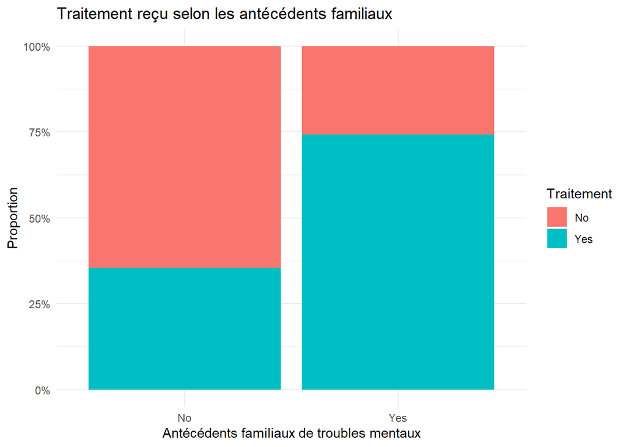

**Interprétation (bref résumé)** :

- Les personnes déclarant des **antécédents familiaux** de troubles mentaux ont une proportion plus élevée de traitement que celles sans antécédents.
- Cela suggère que l’historique familial est un facteur important associé à l’accès ou au recours au traitement.

### 4.2 Interférence avec le travail (Q2)

```
## # A tibble: 5 × 3
##   work_interfere     n  prop
##   <chr>          <int> <dbl>
## 1 Never            213 0.169
## 2 Often            144 0.114
## 3 Rarely           173 0.137
## 4 Sometimes        465 0.369
## 5 <NA>             264 0.210
```

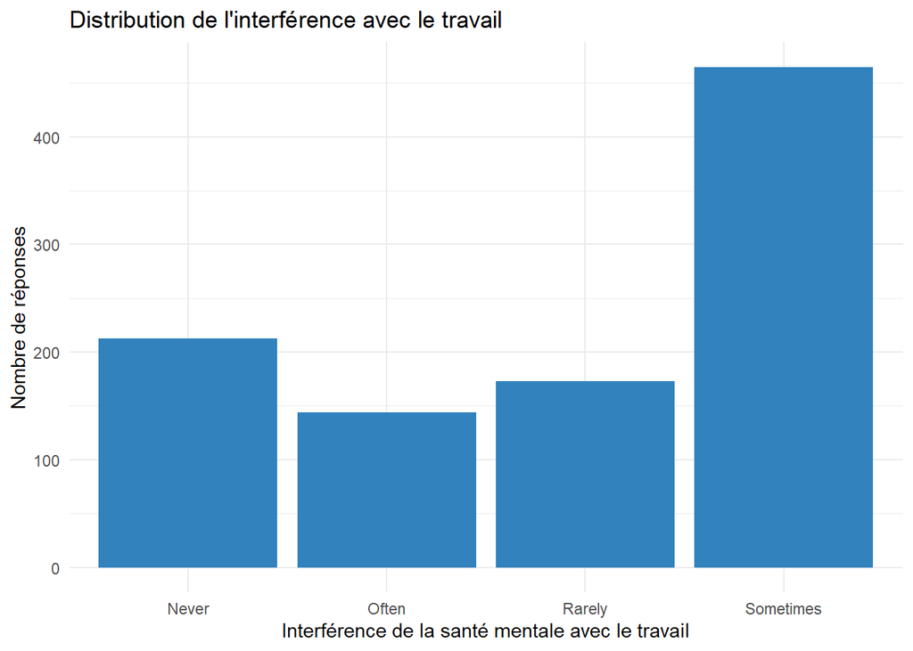

### 4.3 Interférence et climat de l’entreprise

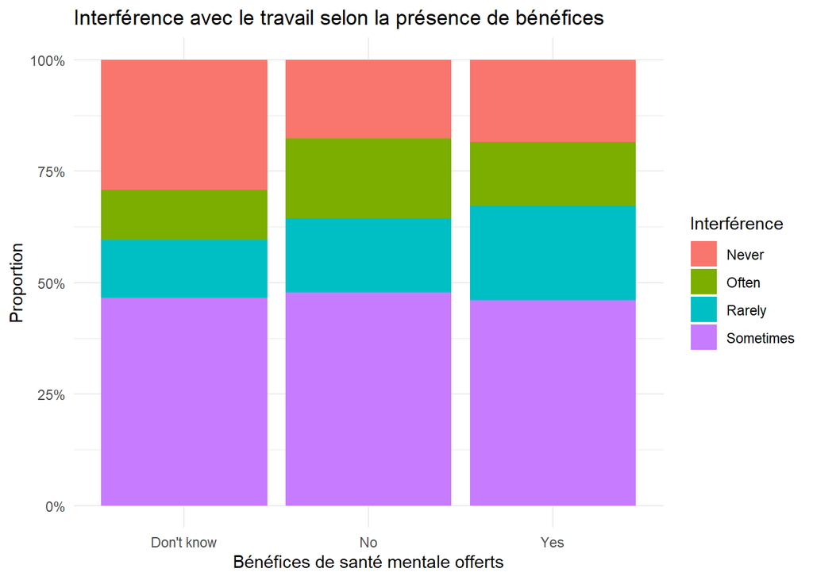

**Interprétation (bref résumé)** :

- Dans les entreprises offrant des **bénéfices de santé mentale**, la proportion de personnes déclarant une forte interférence semble différente de celle observée dans les entreprises sans bénéfices.
- Cela suggère que les politiques de soutien peuvent être liées à la manière dont la santé mentale interfère avec le travail, même si des analyses plus poussées seraient nécessaires pour établir des relations causales.

## 5. Discussion et limites

- Les résultats indiquent des liens plausibles entre antécédents familiaux et traitement, ainsi qu’entre climat organisationnel et interférence avec le travail.
- Cependant, il s’agit de **données observationnelles auto-rapportées**, sujettes à des biais (sélection, mémoire, désirabilité sociale).
- Les variables ne couvrent pas tous les aspects de la santé mentale (diagnostics précis, durée des troubles, types de traitement, etc.).
- Des modèles statistiques plus avancés (par ex. régression logistique pour `treatment`, modèles ordonnés pour `work_interfere`) pourraient affiner les conclusions.

Dans l’ensemble, les analyses mettent en évidence l’importance du contexte personnel (antécédents familiaux) et organisationnel (bénéfices, politiques) pour comprendre la santé mentale dans le secteur technologique.